# calkowanie_numeryczne_2

## Całkowanie numeryczne. Kwadratury Gaussa

Poznane wcześniej kwadratury Newtona-Cotesa, wykorzystujące wielomiany Lagranża stopnia n, dają dokładne wyniki dla wielomianów stopnia < n+1.

Przedstawimy teraz kwadratury Gaussa, które dla niewielkiej liczby węzłów zapewniają rozsądną dokładność obliczeń.

Kwadratury Gaussa można ogólnie przedstawić w postaci

\begin{equation} \label{eq:gkwadr} \int_a^b{p(x)f(x)dx}\approx\sum_{k=0}^n{A_kf(x_k)} \end{equation}

gdzie p(x) jest funkcją wagową, a wspólczynniki kwadratury

\begin{equation} A_k=\int_a^b{p(x)\phi_k(x)dx} \end{equation}

są obliczane z wykorzystaniem wielomianów bazowych

\begin{equation} \label{eq:phi_i} \phi_i(x)=\frac{\prod_{j\neq i}{(x-x_j)}}{\prod_{j\neq i}{(x_i-x_j)}} \end{equation}\begin{textboxa} Zasadniczą różnicą między kwadraturami Newtona-Cotes i kwadraturami Gaussa jest wybór węzłów $x_0,x_1,\ldots,x_n$. W przypadku kwadratur Gaussa węzły są pierwiastkami wielomianów ortogonalnych (Legendra, Czebyszewa, Hermita, Lageurra) \end{textboxa}

#### Kwadratury Gaussa-Legendra

Węzłami tej kwadratury są zera wielomianów Legendra $P_n(x)$, dla których funkcja wagowa $p(x)=1$ i granice całkowania $a=-1$, $b=1$.

Wielomian $P_n(x)$ można obliczyć z formuły

\begin{equation} P_n(x)=\frac{(-1)^n}{2^nn!}\frac{d^n}{dx^n}\left(1-x^2 \right)^n \end{equation}

Inny spsób do obliczenia $P_n(x)$ to użycie funkcji legendre(n) z scipy.special

```python
from scipy.special import legendre
# Pierwsze 4 wielomiany Legendra
print(legendre(1))
print('\n')
print(legendre(2))
print('\n')
print(legendre(3))
print('\n')
print(legendre(4))
print('\n')
```

```
1 x


     2
1.5 x - 0.5


     3
2.5 x - 1.5 x


       4             3        2
4.375 x + 4.857e-16 x - 3.75 x + 2.429e-16 x + 0.375
```

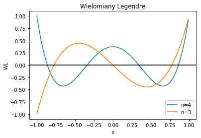

```python
# Wykresy wielomianów Legendra 3 i 4 stopnia
import numpy as np
%matplotlib  inline
import matplotlib.pyplot as plt
wL4=legendre(4)
wL3=legendre(3)
xL=np.arange(-1,1,0.01)
plt.plot(xL,wL4(xL))
plt.plot(xL,wL3(xL))
plt.axhline(y=0,color='k')
plt.xlabel('x')
plt.ylabel('WL')
plt.legend([ 'n=4', 'n=3'], loc='best')
plt.title('Wielomiany Legendre')
plt.show()
```

Węzły $\xi_0,\xi_1,\ldots,\xi_n$ i wspólczynniki $A_0,A_1,\ldots,A_n$ kwadratury Gaussa-Legendra możemy obliczyć korzystając z funkcji roots_legendre() z scipy.special

https://docs.scipy.org/doc/scipy/reference/generated/scipy.special.roots_legendre.html

```python
from scipy.special import roots_legendre
xi,ai=roots_legendre(5)
print(len(ai))
print(xi)
print(ai)
```

```
5
[-0.90617985 -0.53846931  0.          0.53846931  0.90617985]
[0.23692689 0.47862867 0.56888889 0.47862867 0.23692689]
```

\begin{textboxa} Kwadratura Gaussa-Legendra dla dowolnego skończonego przedziału całkowania przybiera postać \end{textboxa}\begin{equation} \label{eq:abGL} \int_a^b{f(x)dx}\approx \frac{b-a}{2}\sum_{k=0}^n{A_kf\left(\frac{b+a}{2}+\frac{b-a}{2}\xi_k\right)} \end{equation}

gdzie $\xi_0,\xi_1,\ldots,\xi_n$ są pierwiastkami wielomianu Legendre'a n+1 stopnia

Sprawdzimy dokładnośc tej kwadratury na całce z funkcji

\begin{equation} \label{eq:ex1} \frac{1}{\sqrt{2\pi}}\int_{-3}^{3}{e^{-x^2/2}dx} \end{equation}

```python
def fzc(x):
    return np.exp(-0.5*x*x)/np.sqrt(2*np.pi)
```

```python
# Zmiana przedziału całkowania z (a,b) na (-1,1)
# I=(b-a)/2*\sum{a[i]*f[(b+a)/2+(b-a)/2*x[i])]}
a=-3
b=3
# wynik z WolframAlpha
Iex1=0.99730020393673981094669637046481004524434126368323870127155602928838855847
s=2
for n in range(3,15):
    xi,ai=roots_legendre(n)
    I_n=0
    for i in range(len(ai)):
        I_n+=(b-a)/2*ai[i]*fzc((b+a)/2+(b-a)/2*xi[i])
    print("%4d  %18.15f  %12.5e" %(n,I_n,Iex1-I_n))
```

```
   3   1.153216482763631  -1.55916e-01
   4   0.957515541751627   3.97847e-02
   5   1.005695397816377  -8.39519e-03
   6   0.995798471361936   1.50173e-03
   7   0.997533062131002  -2.32858e-04
   8   0.997268367586326   3.18364e-05
   9   0.997304094111169  -3.89017e-06
  10   0.997299774399957   4.29537e-07
  11   0.997300247184052  -4.32473e-08
  12   0.997300199935884   4.00086e-09
  13   0.997300204279030  -3.42290e-10
  14   0.997300203909506   2.72338e-11
```

Jeśli chcemy obliczyć całkę za pomocą kwadratury Gaussa dla ustalonego stopnia wielomianu ortogonalnego, to możemy użyć funkcji

fixed_quad(func, a, b, args=(), n=5) z scipy.integrate

https://docs.scipy.org/doc/scipy/reference/generated/scipy.integrate.fixed_quad.html

```python
from scipy.integrate import fixed_quad

a=-3
b=3
for i in range(3,15):
    Ifq=fixed_quad(fzc,a,b,n=i)[0]
    print("%4d  %18.15f  %12.5e" %(i,Ifq,Iex1-Ifq))
```

```
   3   1.153216482763631  -1.55916e-01
   4   0.957515541751627   3.97847e-02
   5   1.005695397816377  -8.39519e-03
   6   0.995798471361936   1.50173e-03
   7   0.997533062131002  -2.32858e-04
   8   0.997268367586325   3.18364e-05
   9   0.997304094111169  -3.89017e-06
  10   0.997299774399957   4.29537e-07
  11   0.997300247184052  -4.32473e-08
  12   0.997300199935884   4.00086e-09
  13   0.997300204279030  -3.42290e-10
  14   0.997300203909506   2.72334e-11
```

Inny przykład

\begin{equation} \label{eq:exc2} \int_0^{\pi/2}{\sin x dx}=1 \end{equation}

```python
#Całka od 0 do pi/2 z sin x
a=0
b=np.pi/2
Iex2=1
for n in range(2,8):
    xi,ai=roots_legendre(n)
    I_n=0
    for i in range(len(ai)):
        I_n+=(b-a)/2*ai[i]*np.sin((b+a)/2+(b-a)/2*xi[i])
    print("%4d  %18.15f  %12.5e" %(len(ai),I_n,Iex2-I_n))
print()
```

```
   2   0.998472613404115   1.52739e-03
   3   1.000008121555498  -8.12156e-06
   4   0.999999977197115   2.28029e-08
   5   1.000000000039565  -3.95650e-11
   6   0.999999999999953   4.66294e-14
   7   1.000000000000000   1.11022e-16
```

Wystarczy 7 węzłów kwadratury Gaussa-Legendre'a, żeby obliczyć całkę (\ref{eq:exc2}) z dużą dokładnością ($\approx 10^{-16}$).

Zobaczmy jakie rezultaty da zastosowanie złożonego wzoru trapezów dp obliczenia tej całki.

```python
# złożony wzór  trapezów
from scipy.integrate import trapz
s=2
for i in range (10):
    s*=2
    zx=np.linspace(a, b,num=s, endpoint=True)
    zy=np.sin(zx)
    wt2=trapz(zy,zx)
    print("%4d  %18.15f  %12.6e" %(s,wt2,Iex2-wt2))
```

```
   4   0.977048616656853  2.295138e-02
   8   0.995800213677537  4.199786e-03
  16   0.999085980671827  9.140193e-04
  32   0.999786029596568  2.139704e-04
  64   0.999948193779589  5.180622e-05
 128   0.999987251702982  1.274830e-05
 256   0.999996837879456  3.162121e-06
 512   0.999999212561262  7.874387e-07
1024   0.999999803525018  1.964750e-07
2048   0.999999950929235  4.907076e-08
```

```python
#porównajmy również z metodą Romberga
from scipy.integrate import romberg
for s in range (2,8):
    wr2=romberg(np.sin,a,b,divmax=s,tol=1e-12,rtol=1e-16)
    print("%4d  %18.15f  %12.5e" %(s,wr2,Iex2-wr2))
```

```
   2   0.999991565472993   8.43453e-06
   3   1.000000008144020  -8.14402e-09
   4   0.999999999998017   1.98286e-12
   5   1.000000000000000  -2.22045e-16
   6   1.000000000000000  -2.22045e-16
   7   1.000000000000000  -2.22045e-16
```

Metodą Romberga uzyskaliśmy wynik z dokładnością rzędu $10^{-16}$ dla divmax=5, czyli dla rekurencyjnych obliczeń ze złożonego wzoru trapezów z liczbą węzłow aż do 32.

\begin{textboxa} Kwadratury Gaussa z n węzłami całkują dokładnie wielomiany stopnia < 2n. \end{textboxa}

Zamiast dowodu przeprowadzimy test całkowania wielomianów.

```python
# wielomian testowy dla n>1;
# całka z tego wielomianu w granicach od -1 do 1 jest równa  1.

def wtest(x,n):
    sum=0
    for i in range(1,n+1):
        sum+=(i+1)*x**i
    if (n%2)==0:
        sum/=n
    else:
        sum/=n-1

    return sum
#całka z wtest(x,n) od -1 do 1 = 1
```

```python
# Użyjemy fixed_quad z n=4, która powinna zwrócić  1 dla wtest(x,2) do wtest(x,7)
for i in range (2,10):
    ict=fixed_quad(wtest,-1,1,args=(i,),n=4)[0]
    print("%4d  %16.12f" %(i,ict))
```

```
   2    1.000000000000
   3    1.000000000000
   4    1.000000000000
   5    1.000000000000
   6    1.000000000000
   7    1.000000000000
   8    0.986938775510
   9    0.986938775510
```

Dodatkową zaletą kwadratury Gaussa jest to, że jej węzły leżą wewnątrz przedziału całkowania. Pozwala to obliczać z duża dokładnością całki typu

\begin{equation} \label{eq:exc3} I=\int_0^2{\frac{sin x}{x}dx}, \end{equation}

z którymi nie radzą sobie metody trapezów, Simpsona i Romberga

```python
def ft3(x):
    return np.sin(x)/x
```

```python
# Obliczenie I kwadraturą Gaussa z n=2,...,9
Iex3=1.6054129768026948485767201481985889408485834223284996602890063065645293571726661498

for i in range (2,10):
    it3=fixed_quad(ft3,0,2,n=i)[0]
    print("%4d  %18.15f   %11.4e" %(i,it3,Iex3-it3))
```

```
   2   1.604453633636794    9.5934e-04
   3   1.605418621604468   -5.6448e-06
   4   1.605412957388674    1.9414e-08
   5   1.605412976846488   -4.3793e-11
   6   1.605412976802625    6.9500e-14
   7   1.605412976802695   -2.2204e-16
   8   1.605412976802695   -2.2204e-16
   9   1.605412976802695    0.0000e+00
```

```python
# Obliczenie I metodą trapezów
for i in range (2,10):
    zx3=np.linspace(0, 2,num=i, endpoint=True)
    zy3=ft3(zx3)
    wt3=trapz(zy3,zx3)
    print("%4d  %18.15f   %11.4e" %(i,wt3,Iex3-wt3))
```

```
   2                 nan           nan
   3                 nan           nan
   4                 nan           nan
   5                 nan           nan
   6                 nan           nan
   7                 nan           nan
   8                 nan           nan
   9                 nan           nan
```

Bezpośrednie zastosowanie metody trapezów zawodzi ponieważ w obliczeniu funkcji podcałkowej w węźle $x=0$ występuje dzielenie przez zero.

Żeby ominąć tę trudnośc zastąpimy dolną granicę $a=0$ wyrażeniem bliskim zeru $a=i^{-2}$ dla i=10,100,1000

```python
# Obliczenie I metodą trapezów z a=1/i**2
i=1
for _ in range (3):
    i*=10
    zx3=np.linspace(1/i**2, 2,num=i, endpoint=True)
    zy3=ft3(zx3)
    wt3=trapz(zy3,zx3)
    print("%6.4e  %18.15f   %11.4e" %(i**(-2),wt3,Iex3-wt3))
```

```
1.0000e-02   1.593651944635375    1.1761e-02
1.0000e-04   1.605298171425150    1.1481e-04
1.0000e-06   1.605411831379653    1.1454e-06
```

```python
# Obliczenie I metodą Romberga z a=0 i a=1e-1,...,1e-10
a=0.0
wr3=romberg(ft3,a,4)
print("%18.15f   %11.4e" %(wr3,Iex3-wr3))
a=1.0
for _ in range(10):
    a/=10.0
    wr3=romberg(ft3,a,2)
    print("%18.15f   %11.4e" %(wr3,Iex3-wr3))
```

```
               nan           nan
 1.505468515693245    9.9944e-02
 1.595413032356023    9.9999e-03
 1.604412976856074    1.0000e-03
 1.605312976800562    1.0000e-04
 1.605402976800506    1.0000e-05
 1.605411976800506    1.0000e-06
 1.605412876800505    1.0000e-07
 1.605412966800505    1.0002e-08
 1.605412975800506    1.0022e-09
 1.605412976700506    1.0219e-10
```

#### Kwadratury Gaussa-Czebyszewa

\begin{textboxa} Kwadratury Gaussa-Czebyszewa stosuje się do całek typu \end{textboxa}\begin{equation} \int_{-1}^{1}{\frac{f(x)}{\sqrt{1-x^2}}dx}\approx\sum_{k=0}^{n}{A_kf(x_k)}, \end{equation}

Funkcja wagowa tej kwadratury jest równa $p(x)=\frac{1}{\sqrt{1-x^2}}$

Węzłami kwadratury Gaussa-Czebyszewa $x_0,x_1,\ldots,x_n$ są pierwiastki wielomianu Czebyszewa n+1 stopnia

\begin{equation} T_{n+1}(x)=\cos\left[(n+1)\cos^{-1}x\right] \end{equation}

mające postać

\begin{equation} x_k=\cos\frac{(2k+1)\pi}{2n+2}, \;\;k=0,1,\ldots,n \end{equation}

Wspólczynniki kwadratury Gaussa-Czebyszewa z n+1 węzłami mają jednakowe wartości

\begin{equation} A_k=\frac{\pi}{n+1}, \;\;k=0,1,\ldots,n \end{equation}

Zastosujemy kwadratury Gaussa-Czebyszewa do obliczenia całki

\begin{equation} \label{eq:iex4} \int_{-1}^{1}{(1-x^2)^{3/2}dx}=\frac{3\pi}{8} \end{equation}

```python
def ft4(x):
    return (1-x**2)**1.5
# Ponieważ w tej kwadraturze  występuje funkcja wagowa p(x)=1/sqrt(1-x**2)
# to musimy przemnożyć funkcję podcałkową przez sqrt(1-x**2)
def ft4p(x):
    return ft4(x)*np.sqrt(1-x**2)

#Teraz kwadratura GC z n węzłami i dla dowolnej funkcji f i granic całkowania

def qgc(f,a,b,n):
    d1=(b+a)/2
    d2=(b-a)/2
    A_k=np.pi/n
    suma=0
    for k in range(n):
        suma+=f(d1+d2*np.cos((2*k+1)*np.pi/(2*n)))
    return d2*A_k*suma
```

```python
iex4=3*np.pi/8
for i in range(2,5):
    itym=qgc(ft4p,-1,1,i)
    print("%2d   %18.14f   %8.4e" %(i,itym,iex4-itym))
```

```
 2     0.78539816339745   3.9270e-01
 3     1.17809724509617   0.0000e+00
 4     1.17809724509617   0.0000e+00
```

Już dla 3 węzłów dostaliśmy wynik dokładny ponieważ funkcja podcałkowa ft4p(x) jest wielomianem 4 stopnia $(1-x^2)^2$. Sprawdzimy teraz jak wypadnie obliczenie całki (\ref{eq:iex4} ) za pomocą kwadratury Gaussa - Legrende'a

```python
for i in range(2,15):
    itym=fixed_quad(ft4,-1,1,n=i)[0]
    print("%2d   %18.14f   %8.4e" %(i,itym,iex4-itym))
```

```
 2     1.08866210790363   8.9435e-02
 3     1.16998023645941   8.1170e-03
 4     1.17622472295142   1.8725e-03
 5     1.17747313412357   6.2411e-04
 6     1.17784026783514   2.5698e-04
 7     1.17797552095421   1.2172e-04
 8     1.17803348529965   6.3760e-05
 9     1.17806120708029   3.6038e-05
10     1.17807562232618   2.1623e-05
11     1.17808363077219   1.3614e-05
12     1.17808832537077   8.9197e-06
13     1.17809120270279   6.0424e-06
14     1.17809303373136   4.2114e-06
```

```python
# Użyjemy teraz funkcji quadrature(), która oblicza całkę  z zadaną dokładnością
# za pomocą kwadratury G_L
from scipy.integrate import quadrature

itym=quadrature(ft4,-1,1)[0]
print(" %18.14f   %8.4e" %(itym,iex4-itym))
itym=quadrature(ft4,-1,1,tol=1.0e-12, rtol=1.0e-18)[0]
print(" %18.14f   %8.4e" %(itym,iex4-itym))
```

```
   1.17809715968981   8.5406e-08
   1.17809723705636   8.0398e-09
```

Drugi przykład zastosowania kwadratury Gaussa-Czebyszewa do obliczenia całki

\begin{equation} \label{eq:iex5} \int_{-1}^{1}{\frac{e^{-x^2}}{\sqrt{1-x^2}}dx} \end{equation}

```python
def ft5(x):
    return np.exp(-x**2)/np.sqrt(1-x**2)
# Ponieważ w tej kwadraturze  występuje funkcja wagowa p(x)=1/sqrt(1-x**2)
# to musimy przemnożyć funkcję podcałkową przez sqrt(1-x**2)
def ft5p(x):
    return np.exp(-x**2)
```

```python
iex5=2.026438066949355305143363055431321234165886963985987646944149610163998860854173184

for i in range(5,15):
    itym=qgc(ft5p,-1,1,i)
    print("%2d   %18.14f   %11.4e" %(i,itym,iex5-itym))
```

```
 5     2.02646940500009   -3.1338e-05
 6     2.02643676313532    1.3038e-06
 7     2.02643811346228   -4.6513e-08
 8     2.02643806549709    1.4523e-09
 9     2.02643806698967   -4.0313e-11
10     2.02643806694835    1.0076e-12
11     2.02643806694938   -2.3093e-14
12     2.02643806694935    4.4409e-16
13     2.02643806694936   -4.4409e-16
14     2.02643806694936    0.0000e+00
```

```python
# Użyjemy teraz kwadratur Gaussa -Legendre'a
for i in range(2,15):
    itym=fixed_quad(ft5,-1,1,n=i*i)[0]
    print("%2d   %18.14f   %8.4e" %(i,itym,iex5-itym))
```

```
 2     1.88742973373746   1.3901e-01
 3     1.95938633682513   6.7052e-02
 4     1.98768595557692   3.8752e-02
 5     2.00133565656815   2.5102e-02
 6     2.00889366574467   1.7544e-02
 7     2.01349900678944   1.2939e-02
 8     2.01650723342922   9.9308e-03
 9     2.01857833237862   7.8597e-03
10     2.02006408328178   6.3740e-03
11     2.02116567463581   5.2724e-03
12     2.02200483366541   4.4332e-03
13     2.02265867743094   3.7794e-03
14     2.02317796791534   3.2601e-03
```

```python
# kwadratura Gaussa -Legendre'a z zadaną dokładnością
itym=quadrature(ft5,-1,1)[0]
print(" %18.14f   %8.4e" %(itym,iex5-itym))
itym=quadrature(ft5,-1,1,tol=1.0e-15, rtol=1.0e-18)[0]
print(" %18.14f   %8.4e" %(itym,iex5-itym))
```

```
   2.01375512137662   1.2683e-02
   2.01375512137662   1.2683e-02
```

Widzimy, że tym przypadku kwadratury Gaussa -Legendre'a dają niezadowalające wyniki

\begin{textboxa} Przetestujemy teraz funkcję quad() z scipy.integrate \end{textboxa}

https://docs.scipy.org/doc/scipy/reference/generated/scipy.integrate.quad.html

(Integrate func from a to b (possibly infinite interval) using a technique from the Fortran library QUADPACK.)

Obliczymy za pomocą quad() wszystkie przykładowe całki

```python
from scipy.integrate import quad

# Pierwsza całka
print('pierwsza całka')
itymq=quad(fzc,-3,3)[0]
print(" %18.14f   %8.4e" %(itymq,Iex1-itymq))

# Druga całka
print('\ndruga całka')
itymq=quad(np.sin,0,np.pi/2)[0]
print(" %18.14f   %8.4e" %(itymq,Iex2-itymq))
# Trzecia całka
print('\ntrzecia całka')
itymq=quad(ft3,0,2)[0]
print(" %18.14f   %8.4e" %(itymq,Iex3-itymq))

# Czwarta całka
print('\nczwarta całka')
itymq=quad(ft4,-1,1)[0]
print(" %18.14f   %8.4e" %(itymq,iex4-itymq))
# Czwarta całka z wieksza dokładnością
print('\nczwarta całka z większą dokładnością')
itymq=quad(ft4,-1,1,epsabs=1e-15,epsrel=1e-18)[0]
print(" %18.14f   %8.4e" %(itymq,iex4-itymq))

# Piąta całka
print('\npiąta całka')
itymq=quad(ft5,-1,1)[0]
print(" %18.14f   %8.4e" %(itymq,iex5-itymq))
```

```
pierwsza całka
   0.99730020393674   -1.1102e-16

druga całka
   1.00000000000000   1.1102e-16

trzecia całka
   1.60541297680269   2.2204e-16

czwarta całka
   1.17809724508050   1.5669e-11

czwarta całka z większą dokładnością
   1.17809724509617   0.0000e+00

piąta całka
   2.02643806694930   5.7288e-14
```

Powyższe przykłady pokazały, że użycie funkcji quad() z domyślną dokładnością daje wyniki z rozsądną precyzją. Najmniejszą dokładność ($10^{-11}$) otrzymaliśmy dla czwartej całki. Jednak, wynik ten można polepszyć zmieniwszy odpowiednio parametry epsabs i epsrel.

\begin{textboxa} Wybór funkcji quad() z scipy.integrate do obliczenia całki jest najlepszym wyborem w ogólnym przypadku \end{textboxa}

Wykorzystanie opcji points w funkcji quad().

Obliczmy całkę (\ref{eq:exc3}) w zmienionych granicach: a=-1, b=1.

```python
it3a=quad(ft3,-1,1)[0]
print(" %18.14f" %(it3a))
```

```
                nan
```

Przyczyną niepowodzenia jest dzielenie przez zero dla x=0. Wykluczmy ten punkt z całkowania za pomocą opcji points=(0). Porównamy wynik takiego podejścia z całkowaniem za pomocą fixed_quad() z parzystą liczbą węzłów.

```python
it3a=quad(ft3,-1,1,points=(0))[0]
it3b=fixed_quad(ft3,-1,1,n=8)[0]
print(" %18.14f" %(it3a))
print(" %18.14f" %(it3b))
```

```
   1.89216614073437
   1.89216614073437
```

#### Obliczanie calki z funkcji zależacej od kilku parametrów

```python
# funkcja x x dwoma parametrmi n, t
def mb(x,n,t):
    return x**(2+n)*np.exp(-x**2/2)*t**n*np.sqrt(2/np.pi)
```

```python
# Całka z  mb(x,n,t) po x od x=0 do x=inf dla t=1 i kilku wartości n
t=1
for i in range(0,7,2):
# wartości parametrów (i,t) przekazujemy do quad() ustawiając args=(i,t)
    cal=quad(mb,0,np.inf,args=(i,t))
    print('%2d   %18.12f'%(i,cal[0]))
```

```
 0       1.000000000000
 2       3.000000000000
 4      15.000000000000
 6     105.000000000000
```

### Obliczanie całek podwójnych

\begin{textboxa} Całkowanie funkcji dwóch zmiennych. Całka podwójna \end{textboxa}\begin{equation} \int_{a}^{b}{dy \int_{g(y)}^{h(y)}{ f(x,y)dx}} \end{equation}

Do obliczenia tej całki możemy użyć dwóch funkcji z scipy.integrate

dblquad() - całkuje funkcje dwóch zmiennych

https://docs.scipy.org/doc/scipy/reference/generated/scipy.integrate.dblquad.html

nquad() - całkuje funkcje wielu zmiennych

https://docs.scipy.org/doc/scipy/reference/generated/scipy.integrate.nquad.html

Zastosujemy obie funkcje do obliczenia przykładowej całki podwójnej

\begin{equation} \int_{0}^{\infty}{dy \int_{0}^{y}{ 4 e^{-x-4y}dx}}=\frac{1}{5} \end{equation}

```python
def fxy(x,y):
    return 4*np.exp(-x-4*y)
# pierwszy argument dla całkowania wewnetrznego
```

```python
from scipy.integrate import dblquad

# deklarujemy funkcję zwracającą dolną granicę calki wewnętrznej
def gfxy(y):
    return 0

# deklarujemy funkcję zwracającą górną granicę calki wewnętrznej
def hfxy(y):
    return y

# wynik dokładny
ixy=1/5

wdxy=dblquad(fxy,0,np.inf,gfxy,hfxy)
print(" %18.14f   %8.4e" %(wdxy[0],ixy-wdxy[0]))
print()
```

```
   0.20000000000000   1.0270e-15
```

```python
# Możemy obliczyć tę całkę w dwóch krokach
# 1. Obliczyć całkę wewnątrzną jako funkcję y
def f(y):
    return quad(fxy,0,y,args=(y,))[0]
print(f(0.5))
```

```
0.21300113845085558
```

```python
# 2. Obliczyć całkę z f jako całkę zewnętrzną
wfy=quad(f,0,np.inf)
print(" %18.14f   %8.4e" %(wfy[0],ixy-wfy[0]))
print()
```

```
   0.20000000000000   1.0270e-15
```

```python
# Teraz użyjemy funkcji nquad
from scipy.integrate import nquad
# deklarujemy  granice całki wewnętrznej
def bondsx(z):
    return [0,z]
# deklarujemy  granice całki zewnętrznej
def bondsy():
    return [0,np.inf]

#Obliczamy całkę podwójną
wnxy=nquad(fxy,[bondsx,bondsy])
print(" %18.14f   %8.4e" %(wnxy[0],ixy-wnxy[0]))
```

```
   0.20000000000000   1.0270e-15
```